# Assignment3

Zuo Siqi

Feb/7

*Source file* ⇒ Assignment3_ZUOSIQI.Rmd

Qn 5.4 Ans:

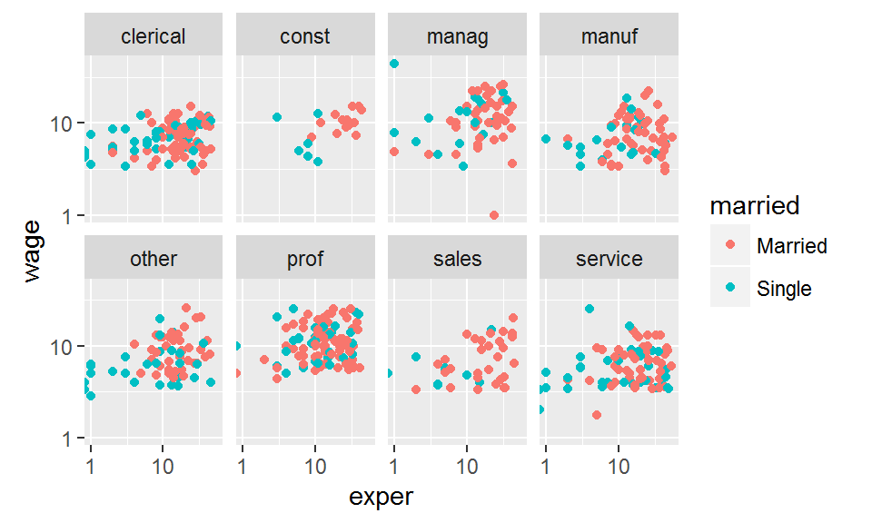

```r
ggplot(data=CPS85,aes(x=exper,y=wage))+geom_point()+aes(colour=married)+scale_x_log10()+scale_y_log10()+facet_wrap(~sector,ncol=4)
```

Qn 6.3 1 Ans:

The bar glyph: x: position of protein y: position of centre dot color : polarity label: name of protein

The star glyph: x: position of protein y: position of high, number of stars: significance

2 Ans: x and y define the frame. Y-axis: cell density for center variable. X-axis: different protein (categorical variable)

3 Ans: NO

4 Ans: Tick on y-axis Label on bar glyphs

Qn 6.6 Ans: d

Qn 6.8 Ans:

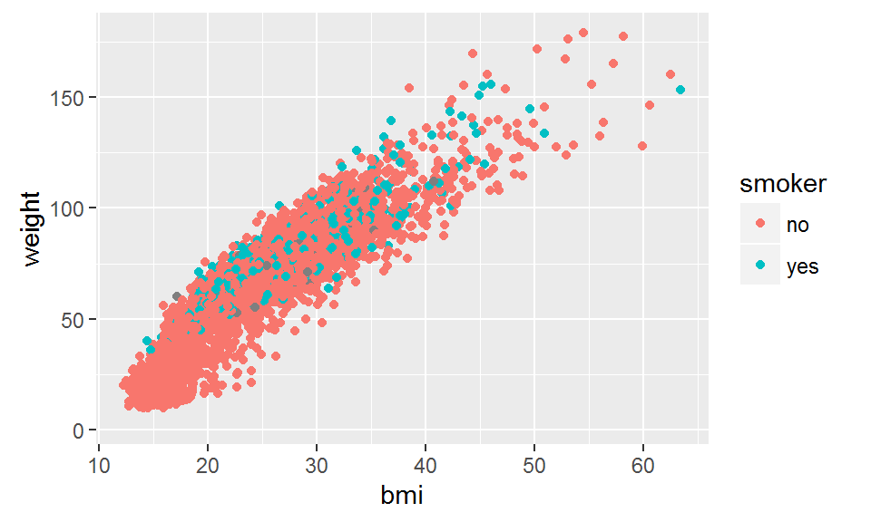

```r
Small <-
NCHS %>%
sample_n(size=5000)

ggplot(data=Small,aes(x=bmi,y=weight))+geom_point()+aes(colour=smoker)
```

x = bmi y = weight color = smoker

Qn 6.2 1 Ans: x => Gene (guide is axis with tick marks and labels) y => Log enzyme concentration (guide is axis with tick and labels) dot-filling : flux (the guide is the filled dot or the unfilled dot) dor-color : Molecule (guide is the color key) the top horizontal axis: target(guide is 3 lines anf label)

2 color: molecule dot-filling: flux x: gene y: log enzyme concentration Only 4 in total for the dot

3 gene and log enzyme concentration

4 gene and target

Qn 7.2 Ans: 1 verb1: group_by verb2: summarise args1: color args2: avg = mean(carat) args3: avg

```r
diamonds %>%
group_by( color ) %>%
summarise( avg = mean(carat) ) %>%
arrange(desc( avg )) %>%
head( 1 )
```

```
## Source: local data frame [1 x 2]
##
##    color      avg
##   (fctr)    (dbl)
## 1      J 1.162137
```

2 verb1: group_by verb2: summaries args1: clarity args2: avg = mean(table/carat) args3: avg

```r
diamonds %>%
group_by( clarity ) %>%
summarise( avg = mean(table/carat) ) %>%
arrange(desc( avg )) %>%
head( 1 )
```

```
## Source: local data frame [1 x 2]
##
##   clarity      avg
##    (fctr)    (dbl)
## 1    VVS1 141.4822
```

Qn 7.4

1 should be group by name instead of first

```r
BabyNames %>%
  group_by( name ) %>%
  summarise( votesReceived=n() )
```

```
## Source: local data frame [92,600 x 2]
##
##         name votesReceived
##        (chr)         (int)
## 1      Aaban             6
## 2      Aabha             2
## 3      Aabid             1
## 4  Aabriella             1
## 5      Aadam            22
## 6      Aadan             8
## 7    Aadarsh            13
## 8      Aaden            14
## 9     Aadesh             3
## 10    Aadhav             7
## ..       ...           ...
```

2 This will be an infinite recursive calls The correct code is

```r
Tmp <- BabyNames %>%
  group_by(year, sex ) %>%
  summarise( totalBirths=sum(count))

  head(Tmp)
```

```
## Source: local data frame [6 x 3]
## Groups: year [3]
##
##    year   sex totalBirths
##   (int) (chr)       (int)
## 1  1880     F       90993
## 2  1880     M      110491
## 3  1881     F       91954
## 4  1881     M      100746
## 5  1882     F      107850
## 6  1882     M      113687
```

3 Missing %>%

```r
Tmp <- BabyNames %>%
  group_by(year, sex) %>%
  summarise(totalBirths=sum(count) )

  head (Tmp)
```

```
## Source: local data frame [6 x 3]
## Groups: year [3]
##
##    year   sex totalBirths
##   (int) (chr)       (int)
## 1  1880     F       90993
## 2  1880     M      110491
## 3  1881     F       91954
## 4  1881     M      100746
## 5  1882     F      107850
## 6  1882     M      113687
```

Qn 7.5

1. arrange(sex, count)

```r
Tmp <- BabyNames %>%
  arrange(sex, count)

  head (Tmp)
```

```
##        name sex count year
## 1    Adelle   F     5 1880
## 2     Adina   F     5 1880
## 3  Adrienne   F     5 1880
## 4 Albertine   F     5 1880
## 5      Alys   F     5 1880
## 6       Ana   F     5 1880
```

2. filter(sex == “F”)

```r
Tmp <- BabyNames %>%
  filter(sex == 'F')

  head (Tmp)
```

```
##        name sex count year
## 1      Mary   F  7065 1880
## 2      Anna   F  2604 1880
## 3      Emma   F  2003 1880
## 4 Elizabeth   F  1939 1880
## 5    Minnie   F  1746 1880
## 6  Margaret   F  1578 1880
```

3. filter(sex == “M”, count > 10)

```r
Tmp <- BabyNames %>%
  filter(sex == 'M', count > 10)

  head (Tmp)
```

```
##      name sex count year
## 1    John   M  9655 1880
## 2 William   M  9532 1880
## 3   James   M  5927 1880
## 4 Charles   M  5348 1880
## 5  George   M  5126 1880
## 6   Frank   M  3242 1880
```

4. summarise(total = sum(count))

```r
Tmp <- BabyNames %>%
  summarise(total = sum(count))

  head (Tmp)
```

```
##       total
## 1 333417770
```

5. select(name, count)

```r
Tmp <- BabyNames %>%
  select(name, count)

  head (Tmp)
```

```
##        name count
## 1      Mary  7065
## 2      Anna  2604
## 3      Emma  2003
## 4 Elizabeth  1939
## 5    Minnie  1746
## 6  Margaret  1578
```

Qn 7.6 1 ans: 80101

```r
  nrow(Minneapolis2013)
```

```
## [1] 80101
```

2 ans:

```r
Minneapolis2013 %>%
    group_by(Second) %>%
    summarise(total = n()) %>%
    arrange(desc(total))
```

```
## Source: local data frame [38 x 2]
##
##                Second total
##                 (chr) (int)
## 1        BETSY HODGES 14399
## 2         DON SAMUELS 14170
## 3         MARK ANDREW 12757
## 4           undervote 10598
## 5  JACKIE CHERRYHOMES  6470
## 6            BOB FINE  3751
## 7          CAM WINTON  3751
## 8           DAN COHEN  2283
## 9  STEPHANIE WOODRUFF  2128
## 10          DOUG MANN  1052
## ..                ...   ...
```

3 ans:

```r
Minneapolis2013 %>%
    filter(First == "undervote") %>%
    summarise(count = n())
```

```
##   count
## 1   834
```

```r
Minneapolis2013 %>%
    filter(Second == "undervote") %>%
    summarise(count = n())
```

```
##   count
## 1 10598
```

```r
Minneapolis2013 %>%
    filter(Third == "undervote") %>%
    summarise(count = n())
```

```
##   count
## 1 19210
```

4 ans:

```r
Minneapolis2013 %>%
    group_by(First, Second) %>%
    summarise(total = n()) %>%
    arrange(desc(total)) %>%
    head(3)
```

```
## Source: local data frame [3 x 3]
## Groups: First [1]
##
##                        First                     Second total
##                        (chr)                      (chr) (int)
## 1 ABDUL M RAHAMAN "THE ROCK"                  undervote   114
## 2 ABDUL M RAHAMAN "THE ROCK" ABDUL M RAHAMAN "THE ROCK"    69
## 3 ABDUL M RAHAMAN "THE ROCK"               BETSY HODGES    29
```

5 ans:

```r
Minneapolis2013 %>%
    group_by(Precinct) %>%
    summarise(total = n()) %>%
    arrange(desc(total)) %>%
    head(1)
```

```
## Source: local data frame [1 x 2]
##
##   Precinct total
##      (chr) (int)
## 1     P-06  9711
```

Qn 8.1 1) Construct the graphics frame: c 2) Add a layer of glyphs: abg 3) Set an axis label: e 4) Divide the frame into facets: fi 5) Change the scale for the frame: dh

Qn 8.2 1

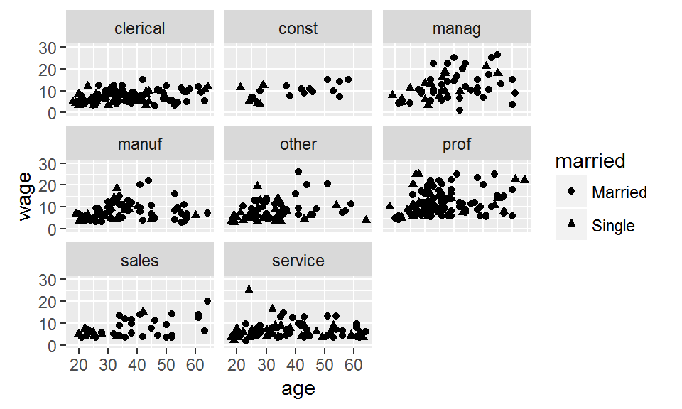

```r
CPS85 %>% ggplot(aes(x = age, y = wage)) + geom_point(aes(shape = married)) + facet_wrap(~ sector) + ylim(0, 30)
```

2

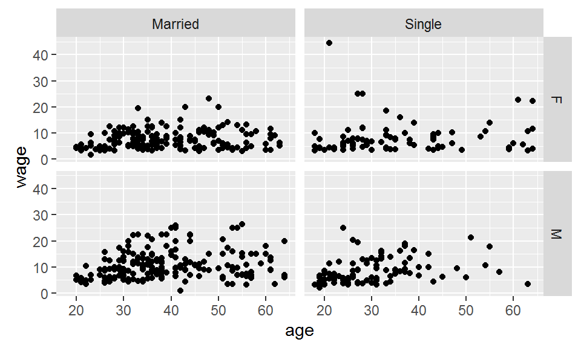

```r
CPS85 %>% ggplot(aes(x = age, y = wage)) + geom_point()  + facet_grid( sex ~ married)
```